# NLP workshop - Exploring Presidential Debate on twitter

Daniel S. Hain (dsh@business.aau.dk)

Updated October 29, 2020

```r
### Load standardpackages
library(tidyverse) # Collection of all the good stuff like dplyr, ggplot2 ect.
library(magrittr) # For extra-piping operators (eg. %<>%)
```

```r
library(tidytext)
```

# Download the data

```r
# download and open some Trump tweets from trump_tweet_data_archive
library(jsonlite)
tmp <- tempfile()
download.file("https://github.com/SDS-AAU/SDS-master/raw/master/M2/data/pol_tweets.gz", tmp)
tweets_raw <- stream_in(gzfile(tmp, "pol_tweets"))
```

```
 Found 1 records...
 Imported 1 records. Simplifying...
```

```r
tweets_raw %>% glimpse()
```

```
Rows: 1
Columns: 2
$ text   <df[,50000]> <data.frame[1 x 50000]>
$ labels <df[,50000]> <data.frame[1 x 50000]>
```

```r
tweets <- tibble(ID = colnames(tweets_raw[[1]]),
                 text = tweets_raw[[1]] %>% as.character(),
                 labels = tweets_raw[[2]] %>% as.logical())
#rm(tweets_raw)
```

```r
tweets %>% glimpse()
```

```
Rows: 50,000
Columns: 3
$ ID     <chr> "340675", "289492", "371088", "82212", "476047", "220741", "379074", "633731", "103805", "401277", "493433", "578814", "570425", "307632", "634542", "276734…
$ text   <chr> "RT @GreenBeretFound Today we remember Sgt. 1st Class Ryan J. Savard killed in action on this day eight years ago. SFC Savard was assigned to U.S. Army Spec…
$ labels <lgl> FALSE, TRUE, TRUE, FALSE, FALSE, TRUE, TRUE, TRUE, TRUE, FALSE, TRUE, FALSE, FALSE, FALSE, TRUE, TRUE, TRUE, FALSE, TRUE, TRUE, TRUE, FALSE, FALSE, TRUE, TR…
```

```r
tweets %<>%
  filter(!(text %>% str_detect('^RT'))) # Filter retweets
```

```r
tweets %>% head()
```

| ID | text | labels |
| --- | --- | --- |
| 289492 | Yes, yes, yes, yes and yes. \U0001f637 #JerseyStrong \U0001f4aa\U0001f3fe https://twitter.com/govmurphy/status/1283111783688024066 QT @GovMurphy Prioritize science over politics.\n\nPrioritize data ov… | TRUE |
| 371088 | Made new friends this afternoon delivering masks to Veterans in St. Pete Beach. Thanks to @StPeteBeachFL Mayor Johnson, Commissioner Graus, and property owner Tom de Yampert for making these homes ava… | TRUE |
| 220741 | "For almost two decades, the US has been home to me."\n \n"Supreme Court must make the right decision, not just for front-line health care workers like me, but for the 700,000 DACA recipients whose ho… | TRUE |
| 379074 | As we emerge from this economic crisis, companies should focus on profit-sharing initiatives. Employee ownership reduces income inequality, improves the employee-employer relationship and drives econo… | TRUE |
| 633731 | Will he transition to using the defense production act to produce more tests, PPE, and medical equipment? https://twitter.com/brianstelter/status/1259942555501944840 QT @brianstelter Trump: "We will t… | TRUE |
| 401277 | Join me in watching this historic moment. #LaunchAmerica https://twitter.com/NASA/status/1266737408944615429 QT @NASA Welcome Back to Launch Day \U0001f680\n\n#LaunchAmerica live coverage starts at 11… | FALSE |

# Tidying

```r
tweets_tidy <- tweets %>%
  unnest_tokens(word, text, token = "tweets")
```

```r
tweets_tidy %>% head(50)
```

| ID | labels | word |
| --- | --- | --- |
| 289492 | TRUE | yes |
| 289492 | TRUE | yes |
| 289492 | TRUE | yes |
| 289492 | TRUE | yes |
| 289492 | TRUE | and |
| 289492 | TRUE | yes |
| 289492 | TRUE | \U0001f637 |
| 289492 | TRUE | #jerseystrong |
| 289492 | TRUE | \U0001f4aa\U0001f3fe |
| 289492 | TRUE | https://twitter.com/govmurphy/status/1283111783688024066 |

[output cut: 40 more lines]

```r
tweets_tidy %>% count(word, sort = TRUE)
```

| word | n |
| --- | --- |
| the | 56358 |
| to | 50755 |
| and | 30440 |
| of | 24142 |
| in | 20140 |
| a | 19755 |
| for | 19374 |
| is | 13532 |
| our | 12069 |
| this | 11923 |

[output cut: 990 more lines]

# Preprocessing

```r
# preprocessing
tweets_tidy %<>%
  filter(!(word %>% str_detect('@'))) %>% # remove hashtags and mentions
  filter(!(word %>% str_detect('^amp|^http|^t\\.co'))) %>% # Twitter specific stuff
#  mutate(word = word %>% str_remove_all('[^[:alnum:]]')) %>% ## remove all special characters
  filter(str_length(word) > 2 ) %>% # Remove words with less than  3 characters
  group_by(word) %>%
  filter(n() > 100) %>% # remove words occuring less than 100 times
  ungroup() %>%
  anti_join(stop_words, by = 'word') # remove stopwords
```

# TFIDF

TFIDF weighting

```r
# top words
tweets_tidy %>%
  count(word, sort = TRUE) %>%
  head(20)
```

| word | n |
| --- | --- |
| health | 3169 |
| people | 2868 |
| trump | 2842 |
| act | 2647 |
| americans | 2419 |
| president | 2415 |
| time | 2148 |
| support | 2125 |
| care | 2089 |
| american | 2039 |

[output cut: 10 more lines]

```r
# TFIDF weights
tweets_tidy %<>%
  add_count(ID, word) %>%
  bind_tf_idf(term = word,
              document = ID,
              n = n)
```

```r
# TFIDF topwords
tweets_tidy %>%
  count(word, wt = tf_idf, sort = TRUE) %>%
  head(20)
```

| word | n |
| --- | --- |
| trump | 741.7387 |
| people | 719.1420 |
| president | 709.3832 |
| time | 688.6194 |
| day | 679.9773 |
| health | 678.7360 |
| vote | 653.3662 |
| americans | 586.7232 |
| support | 584.3217 |
| act | 573.2160 |

[output cut: 10 more lines]

# Inspecting

## Words by party affiliation

```r
labels_words <- tweets_tidy %>%
  group_by(labels) %>%
  count(word, wt = tf_idf, sort = TRUE, name = "tf_idf") %>%
  slice(1:100) %>%
  ungroup()
```

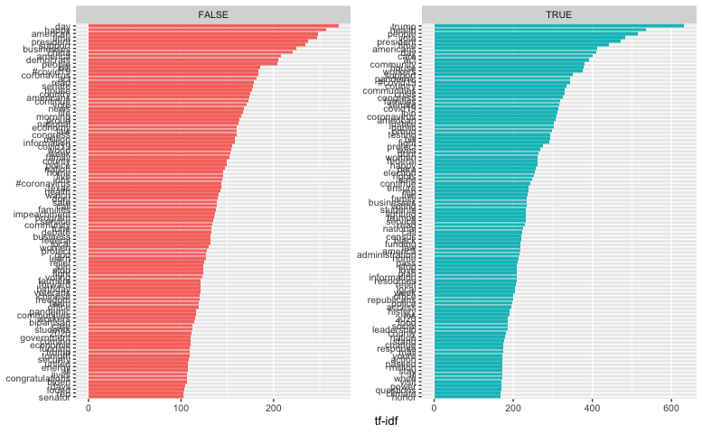

```r
labels_words %>%
  mutate(word = reorder_within(word, by = tf_idf, within = labels)) %>%
  ggplot(aes(x = word, y = tf_idf, fill = labels)) +
  geom_col(show.legend = FALSE) +
  labs(x = NULL, y = "tf-idf") +
  facet_wrap(~labels, ncol = 2, scales = "free") +
  coord_flip() +
  scale_x_reordered()
```

## Distance

```r
tweets_tidy %>% head()
```

| ID | labels | word | n | tf | idf | tf_idf |
| --- | --- | --- | --- | --- | --- | --- |
| 289492 | TRUE | science | 1 | 0.03333333 | 5.154406 | 0.17181353 |
| 289492 | TRUE | politics | 5 | 0.16666667 | 4.723877 | 0.78731281 |
| 289492 | TRUE | data | 1 | 0.03333333 | 4.936351 | 0.16454505 |
| 289492 | TRUE | politics | 5 | 0.16666667 | 4.723877 | 0.78731281 |
| 289492 | TRUE | public | 1 | 0.03333333 | 3.192668 | 0.10642227 |
| 289492 | TRUE | health | 1 | 0.03333333 | 2.376438 | 0.07921461 |

# Predictive model

```r
library(tidymodels)
```

## Simple manual baseline

```r
words_classifier <- labels_words %>%
  arrange(desc(tf_idf)) %>%
  distinct(word, .keep_all = TRUE) %>%
  select(-tf_idf)
```

```r
tweet_null_model <- tweets_tidy %>%
  inner_join(labels_words, by = 'word')
```

```r
null_res <- tweet_null_model %>%
  group_by(ID) %>%
  summarise(truth = mean(labels.x, na.rm = TRUE) %>% round(0),
         pred = mean(labels.y, na.rm = TRUE) %>% round(0))
```

```r
table(null_res$truth, null_res$pred)
```

```
        0     1
  0  8842  2609
  1 11327  9235
```

## Preprocessing

```r
# Notice, we use the initial untokenized tweets
data <- tweets %>%
  select(labels, text) %>%
  rename(y = labels) %>%
  mutate(y = y  %>% as.factor())
```

## Training & Test split

```r
data_split <- initial_split(data, prop = 0.75, strata = y)

data_train <- data_split  %>%  training()
data_test <- data_split %>% testing()
```

## Preprocessing pipeline

```r
library(textrecipes) # Adittional recipes for working with text data
```

```r
# This recipe pretty much reconstructs all preprocessing we did so far
data_recipe <- data_train %>%
  recipe(y ~.) %>%
  themis::step_downsample(y) %>% # For downsampling class imbalances (optimal)
  step_filter(!(text %>% str_detect('^RT'))) %>% # Upfront filtering retweets
  step_filter(text != "") %>%
  step_tokenize(text, token = "tweets") %>% # tokenize
  step_tokenfilter(text, min_times = 75) %>%  # Filter out rare words
  step_stopwords(text, keep = FALSE) %>% # Filter stopwords
  step_tfidf(text) %>% # TFIDF weighting
  #step_pca(all_predictors()) %>% # Dimensionality reduction via PCA (optional)
  prep() # NOTE: Only prep the recipe when not using in a workflow
```

```r
data_recipe
```

```
Data Recipe

Inputs:
```

| role | #variables |
| --- | --- |
| outcome | 1 |
| predictor | 1 |

```
Training data contained 26241 data points and no missing data.

Operations:

Down-sampling based on y [trained]
Row filtering [trained]
Row filtering [trained]
Tokenization for text [trained]
Text filtering for text [trained]
Stop word removal for text [trained]
Term frequency-inverse document frequency with text [trained]
```

Since we will not do hyperparameter tuning, we directly bake/juice the recipe

```r
data_train_prep <- data_recipe %>% juice()
data_test_prep <- data_recipe %>% bake(data_test)
```

## Defining the models

```r
model_en <- logistic_reg(mode = 'classification',
                         mixture = 0.5,
                         penalty = 0.5) %>%
  set_engine('glm', family = binomial)
```

## Define the workflow

We will skip the workflow step this time, since we do not evaluate different models against each others.

## fit the model

```r
fit_en <- model_en %>% fit(formula = y ~., data = data_train_prep)
```

```r
pred_collected <- tibble(
  truth = data_train_prep %>% pull(y),
  pred = fit_en %>% predict(new_data = data_train_prep) %>% pull(.pred_class),
  pred_prob = fit_en %>% predict(new_data = data_train_prep, type = "prob") %>% pull(.pred_TRUE),
  )
```

```r
pred_collected %>% conf_mat(truth, pred)
```

```
          Truth
Prediction FALSE TRUE
     FALSE  6243 4276
     TRUE   3356 5323
```

```r
pred_collected %>% conf_mat(truth, pred) %>% summary()
```

| .metric | .estimator | .estimate |
| --- | --- | --- |
| accuracy | binary | 0.6024586 |
| kap | binary | 0.2049172 |
| sens | binary | 0.6503802 |
| spec | binary | 0.5545369 |
| ppv | binary | 0.5934975 |
| npv | binary | 0.6133195 |
| mcc | binary | 0.2058649 |
| j_index | binary | 0.2049172 |
| bal_accuracy | binary | 0.6024586 |
| detection_prevalence | binary | 0.5479217 |

[output cut: 3 more lines]

Well… soso

# Using the model for new prediction

## Simple test

```r
# How would the model predict given some tweet text
pred_own = tibble(text = 'USA USA WE NEED A WALL TO MAKE AMERICA GREAT AGAIN AND KEEP THE MEXICANS AND ALL REALLY BAD COUNTRIES OUT! AMNERICA FIRST')
```

```r
fit_en %>% predict(new_data = data_recipe %>% bake(pred_own))
```

| .pred_class |
| --- |
| FALSE |

## New data

- We could also use the model to predict on new data, such as the just scraped discussion on the presidential debate.

```r
# download and open some Trump tweets from trump_tweet_data_archive
library(jsonlite)
tmp <- tempfile()
download.file("https://github.com/SDS-AAU/SDS-master/raw/master/M2/data/pres_debate_2020.gz", tmp)
tweets_raw_new <- stream_in(gzfile(tmp, "pres_debate_2020"))
```

```
 Found 1 records...
 Imported 1 records. Simplifying...
```

```r
tweets_raw_new %>% glimpse()
```

```
Rows: 1
Columns: 33
$ id              <df[,8811]> <data.frame[1 x 8811]>
$ conversation_id <df[,8811]> <data.frame[1 x 8811]>
$ created_at      <df[,8811]> <data.frame[1 x 8811]>
$ date            <df[,8811]> <data.frame[1 x 8811]>
$ timezone        <df[,8811]> <data.frame[1 x 8811]>
$ place           <df[,8811]> <data.frame[1 x 8811]>
$ tweet           <df[,8811]> <data.frame[1 x 8811]>
$ language        <df[,8811]> <data.frame[1 x 8811]>
$ hashtags        <df[,8811]> <data.frame[1 x 8811]>
$ cashtags        <df[,8811]> <data.frame[1 x 8811]>
$ user_id         <df[,8811]> <data.frame[1 x 8811]>
$ user_id_str     <df[,8811]> <data.frame[1 x 8811]>
$ username        <df[,8811]> <data.frame[1 x 8811]>
```

[output cut: 20 more lines]

```r
tweets_new <- tibble(ID = tweets_raw_new$id[1,] %>% t() %>% as.character(),
                     text = tweets_raw_new$tweet[1,] %>% t() %>% as.character())
#rm(tweets_raw_new)
```

```r
tweets_new %>% glimpse()
```

```
Rows: 8,811
Columns: 2
$ ID   <chr> "1318944772183281664", "1318938583122743296", "1318932554897031169", "1318928783169245185", "1318927150247018498", "1318926624327454721", "1318926578647207939…
$ text <chr> "Still time to register: Students can join the @UVADemocracy Student Advisory Council for a socially-distanced Presidential Debate Watch Party on Thursday, Oc…
```

```r
data_new <- data_recipe %>% bake(tweets_new)
```

```r
data_new %>% glimpse()
```

```
Rows: 8,811
Columns: 43
$ `tfidf_text_#COVID19`  <dbl> 0, 0, 0, 0, 0, 0, 0, 0, 0, 0, 0, 0, 0, 0, 0, 0, 0, 0, 0, 0, 0, 0, 0, 0, 0, 0, 0, 0, 0, 0, 0, 0, 0, 0, 0, 0, 0, 0, 0, 0, 0, 0, 0, 0, 0, 0, 0,…
$ tfidf_text_act         <dbl> 0, 0, 0, 0, 0, 0, 0, 0, 0, 0, 0, 0, 0, 0, 0, 0, 0, 0, 0, 0, 0, 0, 0, 0, 0, 0, 0, 0, 0, 0, 0, 0, 0, 0, 0, 0, 0, 0, 0, 0, 0, 0, 0, 0, 0, 0, 0,…
$ tfidf_text_american    <dbl> 0.000000, 0.000000, 0.000000, 0.000000, 0.000000, 0.000000, 0.000000, 0.000000, 0.000000, 0.000000, 0.000000, 0.000000, 0.000000, 0.000000, …
$ tfidf_text_americans   <dbl> 0.0000000, 0.0000000, 0.0000000, 0.0000000, 0.0000000, 0.0000000, 0.0000000, 0.0000000, 0.0000000, 0.0000000, 0.0000000, 0.0000000, 0.000000…
$ tfidf_text_amp         <dbl> 0.0000000, 0.0000000, 0.0000000, 0.0000000, 0.0000000, 0.0000000, 0.0000000, 0.0000000, 0.0000000, 0.0000000, 1.9806353, 0.0000000, 0.000000…
$ tfidf_text_bill        <dbl> 0, 0, 0, 0, 0, 0, 0, 0, 0, 0, 0, 0, 0, 0, 0, 0, 0, 0, 0, 0, 0, 0, 0, 0, 0, 0, 0, 0, 0, 0, 0, 0, 0, 0, 0, 0, 0, 0, 0, 0, 0, 0, 0, 0, 0, 0, 0,…
$ tfidf_text_businesses  <dbl> 0, 0, 0, 0, 0, 0, 0, 0, 0, 0, 0, 0, 0, 0, 0, 0, 0, 0, 0, 0, 0, 0, 0, 0, 0, 0, 0, 0, 0, 0, 0, 0, 0, 0, 0, 0, 0, 0, 0, 0, 0, 0, 0, 0, 0, 0, 0,…
$ tfidf_text_can         <dbl> 1.4189092, 0.0000000, 0.0000000, 0.0000000, 0.0000000, 0.0000000, 0.0000000, 0.0000000, 0.0000000, 1.4189092, 0.0000000, 0.0000000, 1.418909…
$ tfidf_text_care        <dbl> 0.000000, 0.000000, 0.000000, 0.000000, 0.000000, 0.000000, 0.000000, 1.670964, 0.000000, 0.000000, 0.000000, 0.000000, 0.000000, 0.000000, …
$ tfidf_text_congress    <dbl> 0, 0, 0, 0, 0, 0, 0, 0, 0, 0, 0, 0, 0, 0, 0, 0, 0, 0, 0, 0, 0, 0, 0, 0, 0, 0, 0, 0, 0, 0, 0, 0, 0, 0, 0, 0, 0, 0, 0, 0, 0, 0, 0, 0, 0, 0, 0,…
$ tfidf_text_coronavirus <dbl> 0, 0, 0, 0, 0, 0, 0, 0, 0, 0, 0, 0, 0, 0, 0, 0, 0, 0, 0, 0, 0, 0, 0, 0, 0, 0, 0, 0, 0, 0, 0, 0, 0, 0, 0, 0, 0, 0, 0, 0, 0, 0, 0, 0, 0, 0, 0,…
$ tfidf_text_country     <dbl> 0, 0, 0, 0, 0, 0, 0, 0, 0, 0, 0, 0, 0, 0, 0, 0, 0, 0, 0, 0, 0, 0, 0, 0, 0, 0, 0, 0, 0, 0, 0, 0, 0, 0, 0, 0, 0, 0, 0, 0, 0, 0, 0, 0, 0, 0, 0,…
$ tfidf_text_covid19     <dbl> 0, 0, 0, 0, 0, 0, 0, 0, 0, 0, 0, 0, 0, 0, 0, 0, 0, 0, 0, 0, 0, 0, 0, 0, 0, 0, 0, 0, 0, 0, 0, 0, 0, 0, 0, 0, 0, 0, 0, 0, 0, 0, 0, 0, 0, 0, 0,…
```

[output cut: 30 more lines]

```r
pred_new <- fit_en %>% predict(new_data = data_new)
```

```r
tweets_new %<>%
  mutate(pred = pred_new %>% pull(.pred_class))
```

```r
tweets_new %>% count(pred)
```

| pred | n |
| --- | --- |
| FALSE | 5376 |
| TRUE | 3435 |

```r
tweets_tidy_new <- tweets_new %>%
  unnest_tokens(word, text, token = "tweets")
```

```r
# preprocessing
tweets_tidy_new %<>%
  filter(!(word %>% str_detect('@|#presidential'))) %>% # remove hashtags and mentions
  filter(!(word %>% str_detect('^amp|^http|^t\\.co'))) %>% # Twitter specific stuff
#  mutate(word = word %>% str_remove_all('[^[:alnum:]]')) %>% ## remove all special characters
  filter(str_length(word) > 2 ) %>% # Remove words with less than  3 characters
  group_by(word) %>%
  filter(n() > 100) %>% # remove words occuring less than 100 times
  ungroup() %>%
  anti_join(stop_words, by = 'word') # remove stopwords
```

```r
# TFIDF weights
tweets_tidy_new %<>%
  add_count(ID, word) %>%
  bind_tf_idf(term = word,
              document = ID,
              n = n)
```

```r
labels_words_new <- tweets_tidy_new %>%
  group_by(pred) %>%
  count(word, wt = tf_idf, sort = TRUE, name = "tf_idf") %>%
  slice(1:20) %>%
  ungroup()
```

```r
hashtags_words_new <- tweets_tidy_new %>%
  filter(word %>% str_detect('#')) %>%
  group_by(pred) %>%
  count(word, wt = tf_idf, sort = TRUE, name = "tf_idf") %>%
  slice(1:20) %>%
  ungroup()
```

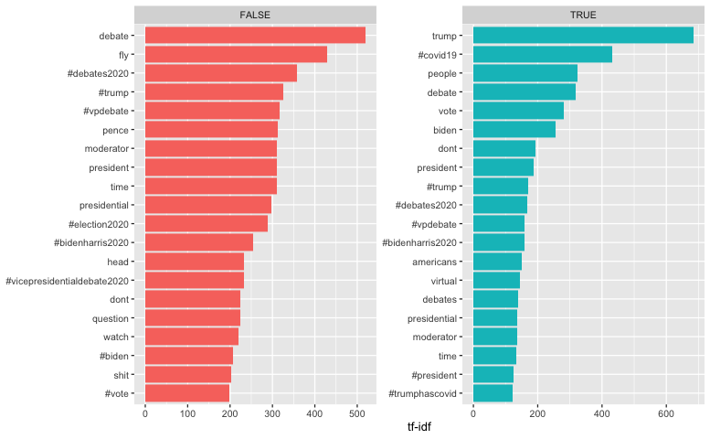

```r
labels_words_new %>%
  mutate(word = reorder_within(word, by = tf_idf, within = pred)) %>%
  ggplot(aes(x = word, y = tf_idf, fill = pred)) +
  geom_col(show.legend = FALSE) +
  labs(x = NULL, y = "tf-idf") +
  facet_wrap(~pred, ncol = 2, scales = "free") +
  coord_flip() +
  scale_x_reordered()
```

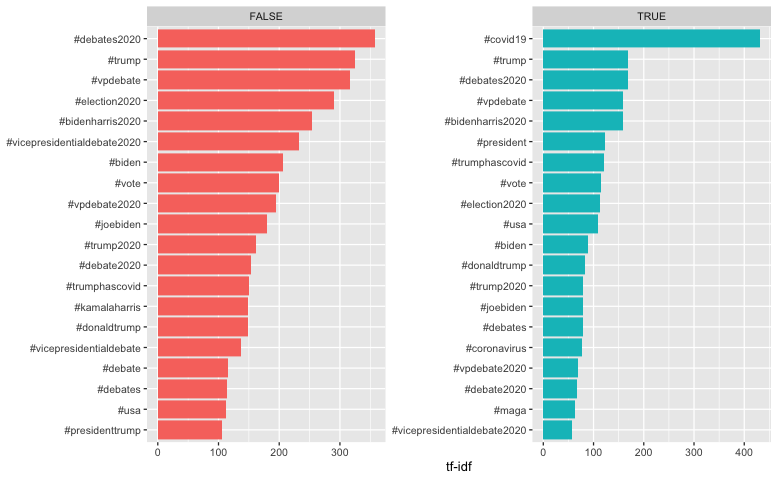

```r
hashtags_words_new %>%
  mutate(word = reorder_within(word, by = tf_idf, within = pred)) %>%
  ggplot(aes(x = word, y = tf_idf, fill = pred)) +
  geom_col(show.legend = FALSE) +
  labs(x = NULL, y = "tf-idf") +
  facet_wrap(~pred, ncol = 2, scales = "free") +
  coord_flip() +
  scale_x_reordered()
```

To be continued by you :)

# Topic models (LDA) on new data

```r
# for LDA analysis
library(topicmodels)
```

### Preparing the Data

```r
# LDA via the topicmodel package requires a document-term-matrix (dtm)
tweets_dtm <- tweets_tidy_new %>%
  cast_dtm(document = ID, term = word, value = n)
```

Lets take a look:

```r
tweets_dtm
```

```
<<DocumentTermMatrix (documents: 7567, terms: 95)>>
Non-/sparse entries: 22637/696228
Sparsity           : 97%
Maximal term length: 27
Weighting          : term frequency (tf)
```

- We see again hat the matrix is still rather sparse, which is an artefact of text data generally, but even more so when using twitter data.
- Lets try to see if we could reduce that somewhat by deleting less often used terms.

```r
library(tm)
tweets_dtm %>% removeSparseTerms(sparse = .99)
```

```
<<DocumentTermMatrix (documents: 7567, terms: 95)>>
Non-/sparse entries: 22637/696228
Sparsity           : 97%
Maximal term length: 27
Weighting          : term frequency (tf)
```

- Now we can perform a LDA, using the more accurate Gibbs sampling as `method`.

```r
tweets_lda <- tweets_dtm %>%
  LDA(k = 6, method = "Gibbs",
      control = list(seed = 1337))
```

### $\beta$: Word-Topic Association

- $\beta$ is an output of the LDA model, indicating the propability that a word occurs in a certain topic.
- Therefore, loking at the top probability words of a topic often gives us a good intuition regarding its properties.

```r
# LDA output is defined for tidy(), so we can easily extract it
lda_beta <- tweets_lda %>%
  tidy(matrix = "beta") %>%
  group_by(topic) %>%
  arrange(topic, desc(beta)) %>%
  slice(1:10) %>%
  ungroup()
```

```r
lda_beta %>% head()
```

| topic | term | beta |
| --- | --- | --- |
| 1 | time | 0.11789342 |
| 1 | dont | 0.09156113 |
| 1 | people | 0.08278370 |
| 1 | questions | 0.05795611 |
| 1 | question | 0.05544828 |
| 1 | hes | 0.04842633 |

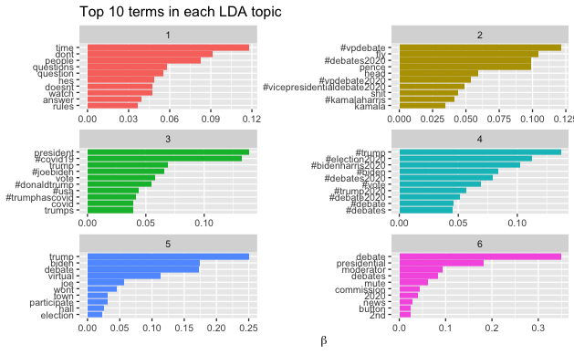

```r
# Notice the "reorder_within()"
lda_beta %>%
  mutate(term = reorder_within(term, beta, topic)) %>%
  group_by(topic, term) %>%
  arrange(desc(beta)) %>%
  ungroup() %>%
  ggplot(aes(term, beta, fill = as.factor(topic))) +
  geom_col(show.legend = FALSE) +
  coord_flip() +
  scale_x_reordered() +
  labs(title = "Top 10 terms in each LDA topic",
       x = NULL, y = expression(beta)) +
  facet_wrap(~ topic, ncol = 2, scales = "free")
```

### $\gamma$: Document-Topic Association

- In LDA, documents are represented as a mix of topics. This association of a document to a topic is captured by $\gamma$

```r
lda_gamma <- tweets_lda %>%
  tidy(matrix = "gamma")
```

```r
lda_gamma %>% head()
```

| document | topic | gamma |
| --- | --- | --- |
| 1318944772183281664 | 1 | 0.1913580 |
| 1318938583122743296 | 1 | 0.1602564 |
| 1318928783169245185 | 1 | 0.1830065 |
| 1318926624327454721 | 1 | 0.1609195 |
| 1318926578647207939 | 1 | 0.1572327 |
| 1318926572653608960 | 1 | 0.1602564 |

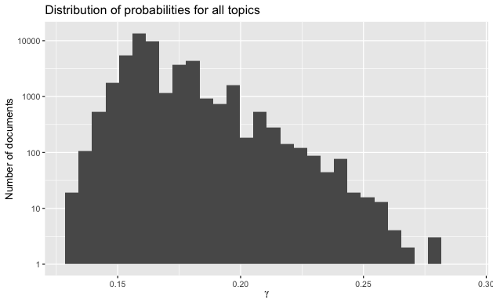

```r
lda_gamma %>%
  ggplot(aes(gamma)) +
  geom_histogram() +
  scale_y_log10() +
  labs(title = "Distribution of probabilities for all topics",
       y = "Number of documents", x = expression(gamma))
```

```r
lda_gamma %<>%
  left_join(tweets_new %>% select(ID, pred), by = c('document' = 'ID'))
```

```r
lda_gamma %>%
  group_by(pred, topic) %>%
  summarise(gamma = sum(gamma)) %>%
  arrange(pred, gamma)
```

| pred | topic | gamma |
| --- | --- | --- |
| FALSE | 5 | 714.3873 |
| FALSE | 3 | 717.6602 |
| FALSE | 1 | 728.1482 |
| FALSE | 6 | 731.1990 |
| FALSE | 4 | 733.2368 |
| FALSE | 2 | 738.3685 |
| TRUE | 2 | 521.6956 |
| TRUE | 4 | 527.7390 |
| TRUE | 6 | 529.5070 |
| TRUE | 1 | 533.7723 |

[output cut: 2 more lines]

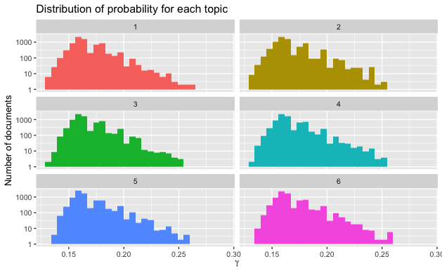

```r
lda_gamma %>%
  ggplot(aes(gamma, fill = as.factor(topic))) +
  geom_histogram(show.legend = FALSE) +
  facet_wrap(~ topic, ncol = 2) +
  scale_y_log10() +
  labs(title = "Distribution of probability for each topic",
       y = "Number of documents", x = expression(gamma))
```

```r
top_topics <- tweets_lda %>%
  tidy(matrix = "gamma")  %>%
  group_by(document) %>%
  top_n(1, wt = gamma) %>%
  ungroup()
```

```r
top_topics %>%
  count(topic)
```

| topic | n |
| --- | --- |
| 1 | 1864 |
| 2 | 1832 |
| 3 | 1799 |
| 4 | 1715 |
| 5 | 1691 |
| 6 | 1689 |

```r
topicmodels_json_ldavis <- function(fitted, doc_dtm, method = "PCA", doc_in = NULL, topic_in = NULL){
  require(topicmodels); require(dplyr); require(LDAvis)

  # Find required quantities
  phi <- posterior(fitted)$terms %>% as.matrix() # Topic-term distribution
  theta <- posterior(fitted)$topics %>% as.matrix() # Document-topic matrix

  # # Restrict (not working atm)
  # if(!is_null(ID_in)){theta <- theta[rownames(theta) %in%  doc_in,]; doc_fm  %<>% dfm_subset(dimnames(doc_fm)$docs %in% doc_in)}

  # Restrict
  if(!is_null(topic_in)){
    phi <- phi[topic_in, ]
    theta <- theta[ , topic_in]
  }
  text_tidy <- doc_dtm %>% tidy()
  vocab <- colnames(phi)
  doc_length <- tibble(document = rownames(theta)) %>% left_join(text_tidy %>% count(document, wt = count), by = 'document')
  tf <- tibble(term = vocab) %>% left_join(text_tidy %>% count(term, wt = count), by = "term")

  if(method == "PCA"){mds <- jsPCA}
  if(method == "TSNE"){library(tsne); mds <- function(x){tsne(svd(x)$u)} }

  # Convert to json
  json_lda <- LDAvis::createJSON(phi = phi, theta = theta, vocab = vocab, doc.length = doc_length %>% pull(n), term.frequency = tf %>% pull(n),
                                 reorder.topics = FALSE, mds.method = mds,plot.opts = list(xlab = "Dim.1", ylab = "Dim.2"))
  return(json_lda)
}
```

```r
library(LDAvis)
json_lda <- topicmodels_json_ldavis(fitted = tweets_lda,
                                    doc_dtm = tweets_dtm,
                                    method = "TSNE")
json_lda %>% serVis()
# json_lda %>% serVis(out.dir = 'LDAviz')
```

# Endnotes

### Packages & Ecosystem

- [`tidytext`](https://github.com/juliasilge/tidytext)
- [`textrecipes`](https://textrecipes.tidymodels.org/)
- [`topicmodels`](https://cran.r-project.org/web/packages/topicmodels/vignettes/topicmodels.pdf)

Further NLP packages ecosystem

- `tm` [here](https://cran.r-project.org/web/packages/tm/)
- `quanteda` [here](https://quanteda.io/), and many many great tutorials [here](https://tutorials.quanteda.io/)

### References

- Julia Silge and David Robinson (2020). Text Mining with R: A Tidy Approach, O’Reilly. Online available [here](https://www.tidytextmining.com/)
  - [Chapter 6](https://www.tidytextmining.com/topicmodeling.html): Introduction topic models
- Emil Hvidfeldt and Julia Silge (2020). Supervised Machine Learning for Text Analysis in R, online available [here](https://smltar.com/)
  - [Chapter 7](https://smltar.com/mlclassification.html): Classification

### Further sources

Datacamp

- [Topic Modeling in R](https://learn.datacamp.com/courses/topic-modeling-in-r)

Other online

- [Julia Silge’s Blog](https://juliasilge.com/): Full of great examples of predictive modeling, NLP, and the combination fo both, using tidy ecosystems